# Welcome to our survey!

We do NOT want you to provide ratings of your own personality – rather, we are interested in your opinion regarding the extent to which each item **should be considered desirable within the context of our United States culture**.

The extent to which personality items reflect desirable content has been of interest to personality researchers for many years. Currently, researchers collect this type of information using two different procedures, and we are curious to know if the procedures yield similar or dissimilar results.

Once we begin, your response time is recorded as well as your actual opinion regarding desirability, so please answer as *quickly but accurately* as possible!

Please hit the `Next` button when you are ready for the instructions for the first rating method.

For this half of the survey, we want you to rate **how desirable** is it to be for someone to be, in our United States culture,

- extremely high (**top 1%** of all people)…
- above average (**top 30%** of all people)…
- neutral (e.g., completely average)…
- below average (**bottom 30%** of all people)…, and
- extremely low (**bottom 1%** of all people)…

…on a number of different characteristics.

Below we provide some examples of how we would like you to think and respond to “how desirable” it would be for a person to be deemed **top 1%**, **top 30%**, average, **bottom 30%** or **bottom 1%** for different characteristics:

## **top 1%**:

This means that very, very few people are more pessimistic than the person.

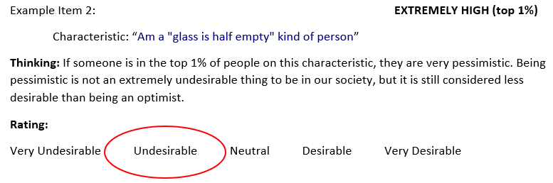

## **top 30%**:

This means that about a third of people are more comfortable than the person.

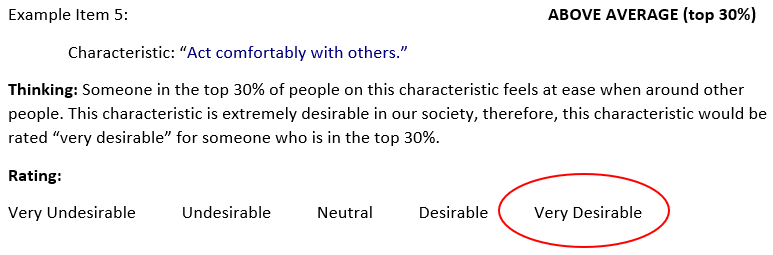

## **AVERAGE:**

This means that the person is perfectly “in the middle” along the characteristic (50% of people have “more” of the characteristic and 50% have “less).

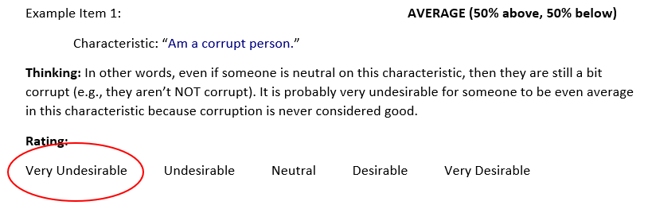

## **bottom 30%**:

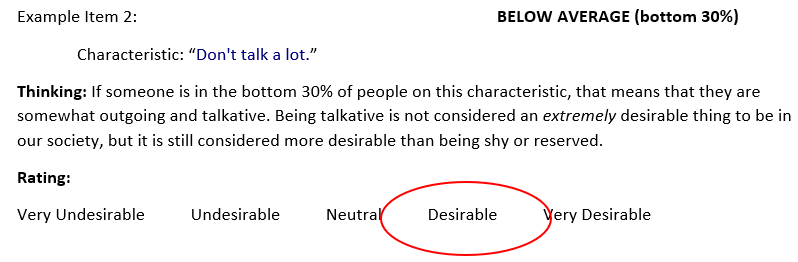

## **bottom 1%**:

This means that very, very few people are “lower” than the person along the characteristic.

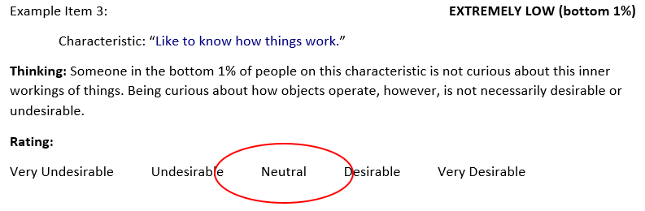

We will be recording *how long it takes for you to respond*, so please respond as quickly but accurately as possible. The next few pages will be *practice* exercises to let you become familiar with the rating procedure – we will let you know when the practice ends and the actual data collection begins.

Please hit the `Next` button when you are ready for your first practice item.

The task we’re asking you to do is unfamiliar to most people. Therefore, before we begin with the **actual** experiment, you will have the chance to *practice* with two items – you also have the opportunity on these 2 items to ask the experimenter questions if you have them.

The first item that you will be asked to provide ratings for is:

## **Readily overcome setbacks.**

Please hit the `Next` button when you are ready to begin the practice session.

## **Readily overcome setbacks.**

How desirable is it to be **Extremely High** in this characteristic? (**top 1%**)

|  | Very Undesirable | Undesirable | Neutral | Desirable | Very Desirable |
| --- | --- | --- | --- | --- | --- |
|  | Very Undesirable Undesirable Neutral Desirable Very Desirable |  |  |  |  |

When ready for the next rating, please hit `Next`:

## **Readily overcome setbacks.**

How desirable is it to be **Above Average** in this characteristic? (**top 30%**)

|  | Very Undesirable | Undesirable | Neutral | Desirable | Very Desirable |
| --- | --- | --- | --- | --- | --- |
|  | Very Undesirable Undesirable Neutral Desirable Very Desirable |  |  |  |  |

When ready for the next rating, please hit `Next`:

## **Readily overcome setbacks.**

How desirable is it to be **Average** in this characteristic?

|  | Very Undesirable | Undesirable | Neutral | Desirable | Very Desirable |
| --- | --- | --- | --- | --- | --- |
|  | Very Undesirable Undesirable Neutral Desirable Very Desirable |  |  |  |  |

When ready for the next rating, please hit `Next`:

## **Readily overcome setbacks.**

How desirable is it to be **Below Average** in this characteristic? (**bottom 30%**)

|  | Very Undesirable | Undesirable | Neutral | Desirable | Very Desirable |
| --- | --- | --- | --- | --- | --- |
|  | Very Undesirable Undesirable Neutral Desirable Very Desirable |  |  |  |  |

When ready for the next rating, please hit `Next`:

## **Readily overcome setbacks.**

How desirable is it to be **Extremely Low** in this characteristic? (**bottom 1%**)

|  | Very Undesirable | Undesirable | Neutral | Desirable | Very Desirable |
| --- | --- | --- | --- | --- | --- |
|  | Very Undesirable Undesirable Neutral Desirable Very Desirable |  |  |  |  |

When ready for the next rating, please hit `Next`:

The SECOND PRACTICE item that you will be asked to provide ratings for is:

## **Easily awakened by noise**

When ready, please hit the `Next` button and you will begin the next sequence of ratings.

## **Easily awakened by noise**

How desirable is it to be **Extremely High** in this characteristic? (**top 1%**)

|  | Very Undesirable | Undesirable | Neutral | Desirable | Very Desirable |
| --- | --- | --- | --- | --- | --- |
|  | Very Undesirable Undesirable Neutral Desirable Very Desirable |  |  |  |  |

When ready for the next rating, please hit `Next`:

## **Easily awakened by noise**

How desirable is it to be **Above Average** in this characteristic? (**top 30%**)

|  | Very Undesirable | Undesirable | Neutral | Desirable | Very Desirable |
| --- | --- | --- | --- | --- | --- |
|  | Very Undesirable Undesirable Neutral Desirable Very Desirable |  |  |  |  |

When ready for the next rating, please hit `Next`:

## **Easily awakened by noise**

How desirable is it to be **Average** in this characteristic?

|  | Very Undesirable | Undesirable | Neutral | Desirable | Very Desirable |
| --- | --- | --- | --- | --- | --- |
|  | Very Undesirable Undesirable Neutral Desirable Very Desirable |  |  |  |  |

When ready for the next rating, please hit `Next`:

## **Easily awakened by noise**

How desirable is it to be **Below Average** in this characteristic? (**bottom 30%**)

|  | Very Undesirable | Undesirable | Neutral | Desirable | Very Desirable |
| --- | --- | --- | --- | --- | --- |
|  | Very Undesirable Undesirable Neutral Desirable Very Desirable |  |  |  |  |

When ready for the next rating, please hit `Next`:

## **Easily awakened by noise**

How desirable is it to be **Extremely Low** in this characteristic? (**bottom 1%**)

|  | Very Undesirable | Undesirable | Neutral | Desirable | Very Desirable |
| --- | --- | --- | --- | --- | --- |
|  | Very Undesirable Undesirable Neutral Desirable Very Desirable |  |  |  |  |

After completing the rating, please hit `Next`:

[figure not shown]

So, that’s the procedure.

The item that you will be asked to provide ratings for is:

## **Use others for my own ends.**

When ready for the next rating, please hit `Next`:

## **Use others for my own ends.**

How desirable is it to be **Extremely High** in this characteristic? (**top 1%**)

|  | Very Undesirable | Undesirable | Neutral | Desirable | Very Desirable |
| --- | --- | --- | --- | --- | --- |
|  | Very Undesirable Undesirable Neutral Desirable Very Desirable |  |  |  |  |

When ready for the next rating, please hit `Next`:

## **Use others for my own ends.**

How desirable is it to be **Above Average** in this characteristic? (**top 30%**)

|  | Very Undesirable | Undesirable | Neutral | Desirable | Very Desirable |
| --- | --- | --- | --- | --- | --- |
|  | Very Undesirable Undesirable Neutral Desirable Very Desirable |  |  |  |  |

When ready for the next rating, please hit `Next`:

## **Use others for my own ends.**

How desirable is it to be **Average** in this characteristic?

|  | Very Undesirable | Undesirable | Neutral | Desirable | Very Desirable |
| --- | --- | --- | --- | --- | --- |
|  | Very Undesirable Undesirable Neutral Desirable Very Desirable |  |  |  |  |

When ready for the next rating, please hit `Next`:

## **Use others for my own ends.**

How desirable is it to be **Below Average** in this characteristic? (**bottom 30%**)

|  | Very Undesirable | Undesirable | Neutral | Desirable | Very Desirable |
| --- | --- | --- | --- | --- | --- |
|  | Very Undesirable Undesirable Neutral Desirable Very Desirable |  |  |  |  |

When ready for the next rating, please hit `Next`:

## **Use others for my own ends.**

How desirable is it to be **Extremely Low** in this characteristic? (**bottom 1%**)

|  | Very Undesirable | Undesirable | Neutral | Desirable | Very Desirable |
| --- | --- | --- | --- | --- | --- |
|  | Very Undesirable Undesirable Neutral Desirable Very Desirable |  |  |  |  |

When ready for the next rating, please hit `Next`:

The item that you will be asked to provide ratings for is:

## **Often make last-minute plans.**

When ready for the next rating, please hit `Next`:

## **Often make last-minute plans.**

How desirable is it to be **Extremely High** in this characteristic? (**top 1%**)

|  | Very Undesirable | Undesirable | Neutral | Desirable | Very Desirable |
| --- | --- | --- | --- | --- | --- |
|  | Very Undesirable Undesirable Neutral Desirable Very Desirable |  |  |  |  |

When ready for the next rating, please hit `Next`:

## **Often make last-minute plans.**

How desirable is it to be **Above Average** in this characteristic? (**top 30%**)

|  | Very Undesirable | Undesirable | Neutral | Desirable | Very Desirable |
| --- | --- | --- | --- | --- | --- |
|  | Very Undesirable Undesirable Neutral Desirable Very Desirable |  |  |  |  |

When ready for the next rating, please hit `Next`:

## **Often make last-minute plans.**

How desirable is it to be **Average** in this characteristic?

|  | Very Undesirable | Undesirable | Neutral | Desirable | Very Desirable |
| --- | --- | --- | --- | --- | --- |
|  | Very Undesirable Undesirable Neutral Desirable Very Desirable |  |  |  |  |

When ready for the next rating, please hit `Next`:

## **Often make last-minute plans.**

How desirable is it to be **Below Average** in this characteristic? (**bottom 30%**)

|  | Very Undesirable | Undesirable | Neutral | Desirable | Very Desirable |
| --- | --- | --- | --- | --- | --- |
|  | Very Undesirable Undesirable Neutral Desirable Very Desirable |  |  |  |  |

When ready for the next rating, please hit `Next`:

## **Often make last-minute plans.**

How desirable is it to be **Extremely Low** in this characteristic? (**bottom 1%**)

|  | Very Undesirable | Undesirable | Neutral | Desirable | Very Desirable |
| --- | --- | --- | --- | --- | --- |
|  | Very Undesirable Undesirable Neutral Desirable Very Desirable |  |  |  |  |

When ready for the next rating, please hit `Next`:

The item that you will be asked to provide ratings for is:

## **Am always busy.**

When ready for the next rating, please hit `Next`:

## **Am always busy.**

How desirable is it to be **Extremely High** in this characteristic? (**top 1%**)

|  | Very Undesirable | Undesirable | Neutral | Desirable | Very Desirable |
| --- | --- | --- | --- | --- | --- |
|  | Very Undesirable Undesirable Neutral Desirable Very Desirable |  |  |  |  |

When ready for the next rating, please hit `Next`:

## **Am always busy.**

How desirable is it to be **Above Average** in this characteristic? (**top 30%**)

|  | Very Undesirable | Undesirable | Neutral | Desirable | Very Desirable |
| --- | --- | --- | --- | --- | --- |
|  | Very Undesirable Undesirable Neutral Desirable Very Desirable |  |  |  |  |

When ready for the next rating, please hit `Next`:

## **Am always busy.**

How desirable is it to be **Average** in this characteristic?

|  | Very Undesirable | Undesirable | Neutral | Desirable | Very Desirable |
| --- | --- | --- | --- | --- | --- |
|  | Very Undesirable Undesirable Neutral Desirable Very Desirable |  |  |  |  |

When ready for the next rating, please hit `Next`:

## **Am always busy.**

How desirable is it to be **Below Average** in this characteristic? (**bottom 30%**)

|  | Very Undesirable | Undesirable | Neutral | Desirable | Very Desirable |
| --- | --- | --- | --- | --- | --- |
|  | Very Undesirable Undesirable Neutral Desirable Very Desirable |  |  |  |  |

When ready for the next rating, please hit `Next`:

## **Am always busy.**

How desirable is it to be **Extremely Low** in this characteristic? (**bottom 1%**)

|  | Very Undesirable | Undesirable | Neutral | Desirable | Very Desirable |
| --- | --- | --- | --- | --- | --- |
|  | Very Undesirable Undesirable Neutral Desirable Very Desirable |  |  |  |  |

When ready for the next rating, please hit `Next`:

The item that you will be asked to provide ratings for is:

## **Believe that we should be tough on crime.**

When ready for the next rating, please hit `Next`:

## **Believe that we should be tough on crime.**

How desirable is it to be **Extremely High** in this characteristic? (**top 1%**)

|  | Very Undesirable | Undesirable | Neutral | Desirable | Very Desirable |
| --- | --- | --- | --- | --- | --- |
|  | Very Undesirable Undesirable Neutral Desirable Very Desirable |  |  |  |  |

When ready for the next rating, please hit `Next`:

## **Believe that we should be tough on crime.**

How desirable is it to be **Above Average** in this characteristic? (**top 30%**)

|  | Very Undesirable | Undesirable | Neutral | Desirable | Very Desirable |
| --- | --- | --- | --- | --- | --- |
|  | Very Undesirable Undesirable Neutral Desirable Very Desirable |  |  |  |  |

When ready for the next rating, please hit `Next`:

## **Believe that we should be tough on crime.**

How desirable is it to be **Average** in this characteristic?

|  | Very Undesirable | Undesirable | Neutral | Desirable | Very Desirable |
| --- | --- | --- | --- | --- | --- |
|  | Very Undesirable Undesirable Neutral Desirable Very Desirable |  |  |  |  |

When ready for the next rating, please hit `Next`:

## **Believe that we should be tough on crime.**

How desirable is it to be **Below Average** in this characteristic? (**bottom 30%**)

|  | Very Undesirable | Undesirable | Neutral | Desirable | Very Desirable |
| --- | --- | --- | --- | --- | --- |
|  | Very Undesirable Undesirable Neutral Desirable Very Desirable |  |  |  |  |

When ready for the next rating, please hit `Next`:

## **Believe that we should be tough on crime.**

How desirable is it to be **Extremely Low** in this characteristic? (**bottom 1%**)

|  | Very Undesirable | Undesirable | Neutral | Desirable | Very Desirable |
| --- | --- | --- | --- | --- | --- |
|  | Very Undesirable Undesirable Neutral Desirable Very Desirable |  |  |  |  |

When ready for the next rating, please hit `Next`:

The item that you will be asked to provide ratings for is:

## **Hold a grudge.**

When ready for the next rating, please hit `Next`:

## **Hold a grudge.**

How desirable is it to be **Extremely High** in this characteristic? (**top 1%**)

|  | Very Undesirable | Undesirable | Neutral | Desirable | Very Desirable |
| --- | --- | --- | --- | --- | --- |
|  | Very Undesirable Undesirable Neutral Desirable Very Desirable |  |  |  |  |

When ready for the next rating, please hit `Next`:

## **Hold a grudge.**

How desirable is it to be **Above Average** in this characteristic? (**top 30%**)

|  | Very Undesirable | Undesirable | Neutral | Desirable | Very Desirable |
| --- | --- | --- | --- | --- | --- |
|  | Very Undesirable Undesirable Neutral Desirable Very Desirable |  |  |  |  |

When ready for the next rating, please hit `Next`:

## **Hold a grudge.**

How desirable is it to be **Average** in this characteristic?

|  | Very Undesirable | Undesirable | Neutral | Desirable | Very Desirable |
| --- | --- | --- | --- | --- | --- |
|  | Very Undesirable Undesirable Neutral Desirable Very Desirable |  |  |  |  |

When ready for the next rating, please hit `Next`:

## **Hold a grudge.**

How desirable is it to be **Below Average** in this characteristic? (**bottom 30%**)

|  | Very Undesirable | Undesirable | Neutral | Desirable | Very Desirable |
| --- | --- | --- | --- | --- | --- |
|  | Very Undesirable Undesirable Neutral Desirable Very Desirable |  |  |  |  |

When ready for the next rating, please hit `Next`:

## **Hold a grudge.**

How desirable is it to be **Extremely Low** in this characteristic? (**bottom 1%**)

|  | Very Undesirable | Undesirable | Neutral | Desirable | Very Desirable |
| --- | --- | --- | --- | --- | --- |
|  | Very Undesirable Undesirable Neutral Desirable Very Desirable |  |  |  |  |

When ready for the next rating, please hit `Next`:

The item that you will be asked to provide ratings for is:

## **Wait for others to lead the way.**

When ready for the next rating, please hit `Next`:

## **Wait for others to lead the way.**

How desirable is it to be **Extremely High** in this characteristic? (**top 1%**)

|  | Very Undesirable | Undesirable | Neutral | Desirable | Very Desirable |
| --- | --- | --- | --- | --- | --- |
|  | Very Undesirable Undesirable Neutral Desirable Very Desirable |  |  |  |  |

When ready for the next rating, please hit `Next`:

## **Wait for others to lead the way.**

How desirable is it to be **Above Average** in this characteristic? (**top 30%**)

|  | Very Undesirable | Undesirable | Neutral | Desirable | Very Desirable |
| --- | --- | --- | --- | --- | --- |
|  | Very Undesirable Undesirable Neutral Desirable Very Desirable |  |  |  |  |

When ready for the next rating, please hit `Next`:

## **Wait for others to lead the way.**

How desirable is it to be **Average** in this characteristic?

|  | Very Undesirable | Undesirable | Neutral | Desirable | Very Desirable |
| --- | --- | --- | --- | --- | --- |
|  | Very Undesirable Undesirable Neutral Desirable Very Desirable |  |  |  |  |

When ready for the next rating, please hit `Next`:

## **Wait for others to lead the way.**

How desirable is it to be **Below Average** in this characteristic? (**bottom 30%**)

|  | Very Undesirable | Undesirable | Neutral | Desirable | Very Desirable |
| --- | --- | --- | --- | --- | --- |
|  | Very Undesirable Undesirable Neutral Desirable Very Desirable |  |  |  |  |

When ready for the next rating, please hit `Next`:

## **Wait for others to lead the way.**

How desirable is it to be **Extremely Low** in this characteristic? (**bottom 1%**)

|  | Very Undesirable | Undesirable | Neutral | Desirable | Very Desirable |
| --- | --- | --- | --- | --- | --- |
|  | Very Undesirable Undesirable Neutral Desirable Very Desirable |  |  |  |  |

When ready for the next rating, please hit `Next`:

The item that you will be asked to provide ratings for is:

## **Get others to do my duties.**

When ready for the next rating, please hit `Next`:

## **Get others to do my duties.**

How desirable is it to be **Extremely High** in this characteristic? (**top 1%**)

|  | Very Undesirable | Undesirable | Neutral | Desirable | Very Desirable |
| --- | --- | --- | --- | --- | --- |
|  | Very Undesirable Undesirable Neutral Desirable Very Desirable |  |  |  |  |

When ready for the next rating, please hit `Next`:

## **Get others to do my duties.**

How desirable is it to be **Above Average** in this characteristic? (**top 30%**)

|  | Very Undesirable | Undesirable | Neutral | Desirable | Very Desirable |
| --- | --- | --- | --- | --- | --- |
|  | Very Undesirable Undesirable Neutral Desirable Very Desirable |  |  |  |  |

When ready for the next rating, please hit `Next`:

## **Get others to do my duties.**

How desirable is it to be **Average** in this characteristic?

|  | Very Undesirable | Undesirable | Neutral | Desirable | Very Desirable |
| --- | --- | --- | --- | --- | --- |
|  | Very Undesirable Undesirable Neutral Desirable Very Desirable |  |  |  |  |

When ready for the next rating, please hit `Next`:

## **Get others to do my duties.**

How desirable is it to be **Below Average** in this characteristic? (**bottom 30%**)

|  | Very Undesirable | Undesirable | Neutral | Desirable | Very Desirable |
| --- | --- | --- | --- | --- | --- |
|  | Very Undesirable Undesirable Neutral Desirable Very Desirable |  |  |  |  |

When ready for the next rating, please hit `Next`:

## **Get others to do my duties.**

How desirable is it to be **Extremely Low** in this characteristic? (**bottom 1%**)

|  | Very Undesirable | Undesirable | Neutral | Desirable | Very Desirable |
| --- | --- | --- | --- | --- | --- |
|  | Very Undesirable Undesirable Neutral Desirable Very Desirable |  |  |  |  |

When ready for the next rating, please hit `Next`:

The item that you will be asked to provide ratings for is:

## **Take charge.**

When ready for the next rating, please hit `Next`:

## **Take charge.**

How desirable is it to be **Extremely High** in this characteristic? (**top 1%**)

|  | Very Undesirable | Undesirable | Neutral | Desirable | Very Desirable |
| --- | --- | --- | --- | --- | --- |
|  | Very Undesirable Undesirable Neutral Desirable Very Desirable |  |  |  |  |

When ready for the next rating, please hit `Next`:

## **Take charge.**

How desirable is it to be **Above Average** in this characteristic? (**top 30%**)

|  | Very Undesirable | Undesirable | Neutral | Desirable | Very Desirable |
| --- | --- | --- | --- | --- | --- |
|  | Very Undesirable Undesirable Neutral Desirable Very Desirable |  |  |  |  |

When ready for the next rating, please hit `Next`:

## **Take charge.**

How desirable is it to be **Average** in this characteristic?

|  | Very Undesirable | Undesirable | Neutral | Desirable | Very Desirable |
| --- | --- | --- | --- | --- | --- |
|  | Very Undesirable Undesirable Neutral Desirable Very Desirable |  |  |  |  |

When ready for the next rating, please hit `Next`:

## **Take charge.**

How desirable is it to be **Below Average** in this characteristic? (**bottom 30%**)

|  | Very Undesirable | Undesirable | Neutral | Desirable | Very Desirable |
| --- | --- | --- | --- | --- | --- |
|  | Very Undesirable Undesirable Neutral Desirable Very Desirable |  |  |  |  |

When ready for the next rating, please hit `Next`:

## **Take charge.**

How desirable is it to be **Extremely Low** in this characteristic? (**bottom 1%**)

|  | Very Undesirable | Undesirable | Neutral | Desirable | Very Desirable |
| --- | --- | --- | --- | --- | --- |
|  | Very Undesirable Undesirable Neutral Desirable Very Desirable |  |  |  |  |

When ready for the next rating, please hit `Next`:

The item that you will be asked to provide ratings for is:

## **Love surprise parties.**

When ready for the next rating, please hit `Next`:

## **Love surprise parties.**

How desirable is it to be **Extremely High** in this characteristic? (**top 1%**)

|  | Very Undesirable | Undesirable | Neutral | Desirable | Very Desirable |
| --- | --- | --- | --- | --- | --- |
|  | Very Undesirable Undesirable Neutral Desirable Very Desirable |  |  |  |  |

When ready for the next rating, please hit `Next`:

## **Love surprise parties.**

How desirable is it to be **Above Average** in this characteristic? (**top 30%**)

|  | Very Undesirable | Undesirable | Neutral | Desirable | Very Desirable |
| --- | --- | --- | --- | --- | --- |
|  | Very Undesirable Undesirable Neutral Desirable Very Desirable |  |  |  |  |

When ready for the next rating, please hit `Next`:

## **Love surprise parties.**

How desirable is it to be **Average** in this characteristic?

|  | Very Undesirable | Undesirable | Neutral | Desirable | Very Desirable |
| --- | --- | --- | --- | --- | --- |
|  | Very Undesirable Undesirable Neutral Desirable Very Desirable |  |  |  |  |

When ready for the next rating, please hit `Next`:

## **Love surprise parties.**

How desirable is it to be **Below Average** in this characteristic? (**bottom 30%**)

|  | Very Undesirable | Undesirable | Neutral | Desirable | Very Desirable |
| --- | --- | --- | --- | --- | --- |
|  | Very Undesirable Undesirable Neutral Desirable Very Desirable |  |  |  |  |

When ready for the next rating, please hit `Next`:

## **Love surprise parties.**

How desirable is it to be **Extremely Low** in this characteristic? (**bottom 1%**)

|  | Very Undesirable | Undesirable | Neutral | Desirable | Very Desirable |
| --- | --- | --- | --- | --- | --- |
|  | Very Undesirable Undesirable Neutral Desirable Very Desirable |  |  |  |  |

When ready for the next rating, please hit `Next`:

The item that you will be asked to provide ratings for is:

## **Believe that there is no absolute right or wrong.**

When ready for the next rating, please hit `Next`:

## **Believe that there is no absolute right or wrong.**

How desirable is it to be **Extremely High** in this characteristic? (**top 1%**)

|  | Very Undesirable | Undesirable | Neutral | Desirable | Very Desirable |
| --- | --- | --- | --- | --- | --- |
|  | Very Undesirable Undesirable Neutral Desirable Very Desirable |  |  |  |  |

When ready for the next rating, please hit `Next`:

## **Believe that there is no absolute right or wrong.**

How desirable is it to be **Above Average** in this characteristic? (**top 30%**)

|  | Very Undesirable | Undesirable | Neutral | Desirable | Very Desirable |
| --- | --- | --- | --- | --- | --- |
|  | Very Undesirable Undesirable Neutral Desirable Very Desirable |  |  |  |  |

When ready for the next rating, please hit `Next`:

## **Believe that there is no absolute right or wrong.**

How desirable is it to be **Average** in this characteristic?

|  | Very Undesirable | Undesirable | Neutral | Desirable | Very Desirable |
| --- | --- | --- | --- | --- | --- |
|  | Very Undesirable Undesirable Neutral Desirable Very Desirable |  |  |  |  |

When ready for the next rating, please hit `Next`:

## **Believe that there is no absolute right or wrong.**

How desirable is it to be **Below Average** in this characteristic? (**bottom 30%**)

|  | Very Undesirable | Undesirable | Neutral | Desirable | Very Desirable |
| --- | --- | --- | --- | --- | --- |
|  | Very Undesirable Undesirable Neutral Desirable Very Desirable |  |  |  |  |

When ready for the next rating, please hit `Next`:

## **Believe that there is no absolute right or wrong.**

How desirable is it to be **Extremely Low** in this characteristic? (**bottom 1%**)

|  | Very Undesirable | Undesirable | Neutral | Desirable | Very Desirable |
| --- | --- | --- | --- | --- | --- |
|  | Very Undesirable Undesirable Neutral Desirable Very Desirable |  |  |  |  |

When ready for the next rating, please hit `Next`:

The item that you will be asked to provide ratings for is:

## **Am not bothered by disorder.**

When ready for the next rating, please hit `Next`:

## **Am not bothered by disorder.**

How desirable is it to be **Extremely High** in this characteristic? (**top 1%**)

|  | Very Undesirable | Undesirable | Neutral | Desirable | Very Desirable |
| --- | --- | --- | --- | --- | --- |
|  | Very Undesirable Undesirable Neutral Desirable Very Desirable |  |  |  |  |

When ready for the next rating, please hit `Next`:

## **Am not bothered by disorder.**

How desirable is it to be **Above Average** in this characteristic? (**top 30%**)

|  | Very Undesirable | Undesirable | Neutral | Desirable | Very Desirable |
| --- | --- | --- | --- | --- | --- |
|  | Very Undesirable Undesirable Neutral Desirable Very Desirable |  |  |  |  |

When ready for the next rating, please hit `Next`:

## **Am not bothered by disorder.**

How desirable is it to be **Average** in this characteristic?

|  | Very Undesirable | Undesirable | Neutral | Desirable | Very Desirable |
| --- | --- | --- | --- | --- | --- |
|  | Very Undesirable Undesirable Neutral Desirable Very Desirable |  |  |  |  |

When ready for the next rating, please hit `Next`:

## **Am not bothered by disorder.**

How desirable is it to be **Below Average** in this characteristic? (**bottom 30%**)

|  | Very Undesirable | Undesirable | Neutral | Desirable | Very Desirable |
| --- | --- | --- | --- | --- | --- |
|  | Very Undesirable Undesirable Neutral Desirable Very Desirable |  |  |  |  |

When ready for the next rating, please hit `Next`:

## **Am not bothered by disorder.**

How desirable is it to be **Extremely Low** in this characteristic? (**bottom 1%**)

|  | Very Undesirable | Undesirable | Neutral | Desirable | Very Desirable |
| --- | --- | --- | --- | --- | --- |
|  | Very Undesirable Undesirable Neutral Desirable Very Desirable |  |  |  |  |

When ready for the next rating, please hit `Next`:

The item that you will be asked to provide ratings for is:

## **Cheer people up.**

When ready for the next rating, please hit `Next`:

## **Cheer people up.**

How desirable is it to be **Extremely High** in this characteristic? (**top 1%**)

|  | Very Undesirable | Undesirable | Neutral | Desirable | Very Desirable |
| --- | --- | --- | --- | --- | --- |
|  | Very Undesirable Undesirable Neutral Desirable Very Desirable |  |  |  |  |

When ready for the next rating, please hit `Next`:

## **Cheer people up.**

How desirable is it to be **Above Average** in this characteristic? (**top 30%**)

|  | Very Undesirable | Undesirable | Neutral | Desirable | Very Desirable |
| --- | --- | --- | --- | --- | --- |
|  | Very Undesirable Undesirable Neutral Desirable Very Desirable |  |  |  |  |

When ready for the next rating, please hit `Next`:

## **Cheer people up.**

How desirable is it to be **Average** in this characteristic?

|  | Very Undesirable | Undesirable | Neutral | Desirable | Very Desirable |
| --- | --- | --- | --- | --- | --- |
|  | Very Undesirable Undesirable Neutral Desirable Very Desirable |  |  |  |  |

When ready for the next rating, please hit `Next`:

## **Cheer people up.**

How desirable is it to be **Below Average** in this characteristic? (**bottom 30%**)

|  | Very Undesirable | Undesirable | Neutral | Desirable | Very Desirable |
| --- | --- | --- | --- | --- | --- |
|  | Very Undesirable Undesirable Neutral Desirable Very Desirable |  |  |  |  |

When ready for the next rating, please hit `Next`:

## **Cheer people up.**

How desirable is it to be **Extremely Low** in this characteristic? (**bottom 1%**)

|  | Very Undesirable | Undesirable | Neutral | Desirable | Very Desirable |
| --- | --- | --- | --- | --- | --- |
|  | Very Undesirable Undesirable Neutral Desirable Very Desirable |  |  |  |  |

When ready for the next rating, please hit `Next`:

The item that you will be asked to provide ratings for is:

## **Break rules.**

When ready for the next rating, please hit `Next`:

## **Break rules.**

How desirable is it to be **Extremely High** in this characteristic? (**top 1%**)

|  | Very Undesirable | Undesirable | Neutral | Desirable | Very Desirable |
| --- | --- | --- | --- | --- | --- |
|  | Very Undesirable Undesirable Neutral Desirable Very Desirable |  |  |  |  |

When ready for the next rating, please hit `Next`:

## **Break rules.**

How desirable is it to be **Above Average** in this characteristic? (**top 30%**)

|  | Very Undesirable | Undesirable | Neutral | Desirable | Very Desirable |
| --- | --- | --- | --- | --- | --- |
|  | Very Undesirable Undesirable Neutral Desirable Very Desirable |  |  |  |  |

When ready for the next rating, please hit `Next`:

## **Break rules.**

How desirable is it to be **Average** in this characteristic?

|  | Very Undesirable | Undesirable | Neutral | Desirable | Very Desirable |
| --- | --- | --- | --- | --- | --- |
|  | Very Undesirable Undesirable Neutral Desirable Very Desirable |  |  |  |  |

When ready for the next rating, please hit `Next`:

## **Break rules.**

How desirable is it to be **Below Average** in this characteristic? (**bottom 30%**)

|  | Very Undesirable | Undesirable | Neutral | Desirable | Very Desirable |
| --- | --- | --- | --- | --- | --- |
|  | Very Undesirable Undesirable Neutral Desirable Very Desirable |  |  |  |  |

When ready for the next rating, please hit `Next`:

## **Break rules.**

How desirable is it to be **Extremely Low** in this characteristic? (**bottom 1%**)

|  | Very Undesirable | Undesirable | Neutral | Desirable | Very Desirable |
| --- | --- | --- | --- | --- | --- |
|  | Very Undesirable Undesirable Neutral Desirable Very Desirable |  |  |  |  |

When ready for the next rating, please hit `Next`:

The item that you will be asked to provide ratings for is:

## **Do not enjoy going to art museums.**

When ready for the next rating, please hit `Next`:

## **Do not enjoy going to art museums.**

How desirable is it to be **Extremely High** in this characteristic? (**top 1%**)

|  | Very Undesirable | Undesirable | Neutral | Desirable | Very Desirable |
| --- | --- | --- | --- | --- | --- |
|  | Very Undesirable Undesirable Neutral Desirable Very Desirable |  |  |  |  |

When ready for the next rating, please hit `Next`:

## **Do not enjoy going to art museums.**

How desirable is it to be **Above Average** in this characteristic? (**top 30%**)

|  | Very Undesirable | Undesirable | Neutral | Desirable | Very Desirable |
| --- | --- | --- | --- | --- | --- |
|  | Very Undesirable Undesirable Neutral Desirable Very Desirable |  |  |  |  |

When ready for the next rating, please hit `Next`:

## **Do not enjoy going to art museums.**

How desirable is it to be **Average** in this characteristic?

|  | Very Undesirable | Undesirable | Neutral | Desirable | Very Desirable |
| --- | --- | --- | --- | --- | --- |
|  | Very Undesirable Undesirable Neutral Desirable Very Desirable |  |  |  |  |

When ready for the next rating, please hit `Next`:

## **Do not enjoy going to art museums.**

How desirable is it to be **Below Average** in this characteristic? (**bottom 30%**)

|  | Very Undesirable | Undesirable | Neutral | Desirable | Very Desirable |
| --- | --- | --- | --- | --- | --- |
|  | Very Undesirable Undesirable Neutral Desirable Very Desirable |  |  |  |  |

When ready for the next rating, please hit `Next`:

## **Do not enjoy going to art museums.**

How desirable is it to be **Extremely Low** in this characteristic? (**bottom 1%**)

|  | Very Undesirable | Undesirable | Neutral | Desirable | Very Desirable |
| --- | --- | --- | --- | --- | --- |
|  | Very Undesirable Undesirable Neutral Desirable Very Desirable |  |  |  |  |

When ready for the next rating, please hit `Next`:

[figure not shown]

Thank you for your responses!

Please notify the experimenter (across the room from you – 478B) that you are ready for the next portion of the experiment!

For this half of the survey, we want you to rate **how desirable** is it to be for someone to be, in our United States culture, across a number of different characteristics.

Below we provide some examples of how we would like you to think and respond to “how desirable” it would be for a person to be characterized by different statements.

Rate each personality characteristic on how desirable it is in others. You may want to think about the behavior of people who have this trait and then rate the desirability.

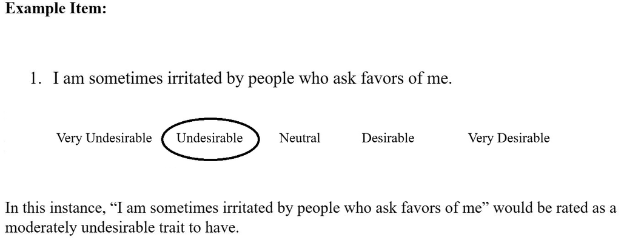

The task we’re asking you to do is unfamiliar to most people. Therefore, before we begin with the **actual** experiment, you will have the chance to *practice* with two items – you also have the opportunity on these 2 items to ask the experimenter questions if you have them.

The FIRST PRACTICE item that you will be asked to provide ratings for is:

## **Readily overcome setbacks.**

Please hit the `Next` button when you are ready to begin the practice session.

## **Readily overcome setbacks.**

How desirable is this characteristic?

|  | Very Undesirable | Undesirable | Neutral | Desirable | Very Desirable |
| --- | --- | --- | --- | --- | --- |
|  | Very Undesirable Undesirable Neutral Desirable Very Desirable |  |  |  |  |

When ready for the next rating, please hit `Next`:

The SECOND PRACTICE item that you will be asked to provide ratings for is:

## **Easily awakened by noise**

Please hit the `Next` button when you are ready to begin the rating.

## **Easily awakened by noise**

How desirable is this characteristic?

|  | Very Undesirable | Undesirable | Neutral | Desirable | Very Desirable |
| --- | --- | --- | --- | --- | --- |
|  | Very Undesirable Undesirable Neutral Desirable Very Desirable |  |  |  |  |

When ready for the next rating, please hit `Next`:

[figure not shown]

So, that’s the procedure.

The item that you will be asked to provide ratings for is:

## **Use others for my own ends.**

When ready for the next rating, please hit `Next`:

## **Use others for my own ends.**

How desirable is this characteristic?

|  | Very Undesirable | Undesirable | Neutral | Desirable | Very Desirable |
| --- | --- | --- | --- | --- | --- |
|  | Very Undesirable Undesirable Neutral Desirable Very Desirable |  |  |  |  |

When ready for the next rating, please hit `Next`:

The item that you will be asked to provide ratings for is:

## **Often make last-minute plans.**

When ready for the next rating, please hit `Next`:

## **Often make last-minute plans.**

How desirable is this characteristic?

|  | Very Undesirable | Undesirable | Neutral | Desirable | Very Desirable |
| --- | --- | --- | --- | --- | --- |
|  | Very Undesirable Undesirable Neutral Desirable Very Desirable |  |  |  |  |

When ready for the next rating, please hit `Next`:

The item that you will be asked to provide ratings for is:

## **Am always busy.**

When ready for the next rating, please hit `Next`:

## **Am always busy.**

How desirable is this characteristic?

|  | Very Undesirable | Undesirable | Neutral | Desirable | Very Desirable |
| --- | --- | --- | --- | --- | --- |
|  | Very Undesirable Undesirable Neutral Desirable Very Desirable |  |  |  |  |

When ready for the next rating, please hit `Next`:

The item that you will be asked to provide ratings for is:

## **Believe that we should be tough on crime.**

When ready for the next rating, please hit `Next`:

## **Believe that we should be tough on crime.**

How desirable is this characteristic?

|  | Very Undesirable | Undesirable | Neutral | Desirable | Very Desirable |
| --- | --- | --- | --- | --- | --- |
|  | Very Undesirable Undesirable Neutral Desirable Very Desirable |  |  |  |  |

When ready for the next rating, please hit `Next`:

The item that you will be asked to provide ratings for is:

## **Hold a grudge.**

When ready for the next rating, please hit `Next`:

## **Hold a grudge.**

How desirable is this characteristic?

|  | Very Undesirable | Undesirable | Neutral | Desirable | Very Desirable |
| --- | --- | --- | --- | --- | --- |
|  | Very Undesirable Undesirable Neutral Desirable Very Desirable |  |  |  |  |

When ready for the next rating, please hit `Next`:

The item that you will be asked to provide ratings for is:

## **Wait for others to lead the way.**

When ready for the next rating, please hit `Next`:

## **Wait for others to lead the way.**

How desirable is this characteristic?

|  | Very Undesirable | Undesirable | Neutral | Desirable | Very Desirable |
| --- | --- | --- | --- | --- | --- |
|  | Very Undesirable Undesirable Neutral Desirable Very Desirable |  |  |  |  |

When ready for the next rating, please hit `Next`:

The item that you will be asked to provide ratings for is:

## **Get others to do my duties.**

When ready for the next rating, please hit `Next`:

## **Get others to do my duties.**

How desirable is this characteristic?

|  | Very Undesirable | Undesirable | Neutral | Desirable | Very Desirable |
| --- | --- | --- | --- | --- | --- |
|  | Very Undesirable Undesirable Neutral Desirable Very Desirable |  |  |  |  |

When ready for the next rating, please hit `Next`:

The item that you will be asked to provide ratings for is:

## **Take charge.**

When ready for the next rating, please hit `Next`:

## **Take charge.**

How desirable is this characteristic?

|  | Very Undesirable | Undesirable | Neutral | Desirable | Very Desirable |
| --- | --- | --- | --- | --- | --- |
|  | Very Undesirable Undesirable Neutral Desirable Very Desirable |  |  |  |  |

When ready for the next rating, please hit `Next`:

The item that you will be asked to provide ratings for is:

## **Love surprise parties.**

When ready for the next rating, please hit `Next`:

## **Love surprise parties.**

How desirable is this characteristic?

|  | Very Undesirable | Undesirable | Neutral | Desirable | Very Desirable |
| --- | --- | --- | --- | --- | --- |
|  | Very Undesirable Undesirable Neutral Desirable Very Desirable |  |  |  |  |

When ready for the next rating, please hit `Next`:

The item that you will be asked to provide ratings for is:

## **Believe that there is no absolute right or wrong.**

When ready for the next rating, please hit `Next`:

## **Believe that there is no absolute right or wrong.**

How desirable is this characteristic?

|  | Very Undesirable | Undesirable | Neutral | Desirable | Very Desirable |
| --- | --- | --- | --- | --- | --- |
|  | Very Undesirable Undesirable Neutral Desirable Very Desirable |  |  |  |  |

When ready for the next rating, please hit `Next`:

The item that you will be asked to provide ratings for is:

## **Am not bothered by disorder.**

When ready for the next rating, please hit `Next`:

## **Am not bothered by disorder.**

How desirable is this characteristic?

|  | Very Undesirable | Undesirable | Neutral | Desirable | Very Desirable |
| --- | --- | --- | --- | --- | --- |
|  | Very Undesirable Undesirable Neutral Desirable Very Desirable |  |  |  |  |

When ready for the next rating, please hit `Next`:

The item that you will be asked to provide ratings for is:

## **Cheer people up.**

When ready for the next rating, please hit `Next`:

## **Cheer people up.**

How desirable is this characteristic?

|  | Very Undesirable | Undesirable | Neutral | Desirable | Very Desirable |
| --- | --- | --- | --- | --- | --- |
|  | Very Undesirable Undesirable Neutral Desirable Very Desirable |  |  |  |  |

When ready for the next rating, please hit `Next`:

The item that you will be asked to provide ratings for is:

## **Break rules.**

When ready for the next rating, please hit `Next`:

## **Break rules.**

How desirable is this characteristic?

|  | Very Undesirable | Undesirable | Neutral | Desirable | Very Desirable |
| --- | --- | --- | --- | --- | --- |
|  | Very Undesirable Undesirable Neutral Desirable Very Desirable |  |  |  |  |

When ready for the next rating, please hit `Next`:

The item that you will be asked to provide ratings for is:

## **Do not enjoy going to art museums.**

When ready for the next rating, please hit `Next`:

## **Do not enjoy going to art museums.**

How desirable is this characteristic?

|  | Very Undesirable | Undesirable | Neutral | Desirable | Very Desirable |
| --- | --- | --- | --- | --- | --- |
|  | Very Undesirable Undesirable Neutral Desirable Very Desirable |  |  |  |  |

When ready for the next rating, please hit `Next`:

## Thank you!!

[figure not shown]

All of your responses have been recorded – you can retrieve the experimenter and close this window now.